# biol792ch12hw

morgan hrivnak

2024-11-05

Monsters and Mixtures

12E1, Ordered categorical variables are variables that have quantitative dimension that can be ordered and not on a regular scale. Their values can be ordered meaningfully from one extreme to the another without implying equal distaces between the values. Unordered categorical values are similar but can not be ordered in a meaningful way.

12E2. Cumulative logit link function employs an ordered logistic regression.It states that the linear model defines the log-cumulative odds of an event. It is a more refined version of the ordinary logit link.

12E3. If a count is zero-inflated than the counts of zero arise through more than one process at least one of which is not accounted for in the model. Estimates of the true rate are closer to 0 than it actually is a result of under preduction of the true rate of events.

12E4. Over dispersion occurs when theres is high varriation amonst sampling a system. Count data on fish across the Missouri river over the course a decade would result in data that is varried due to the different areas on the Missouri. Under-dispersion would result in a much more frequent interval of time, Say that you sample everyday the data would be highly autocrrelated.

12M1.

```r
n <- c(12, 36, 7, 41) # assignment
q <- n / sum(n) # proportions
p <- cumsum(q) # cumulative proportions
o <- p / (1 - p) # cumulative odds
log(o) # log-cumulative odds
```

```
## [1] -1.9459101  0.0000000  0.2937611        Inf
```

12M2.

```r
library(rethinking)
```

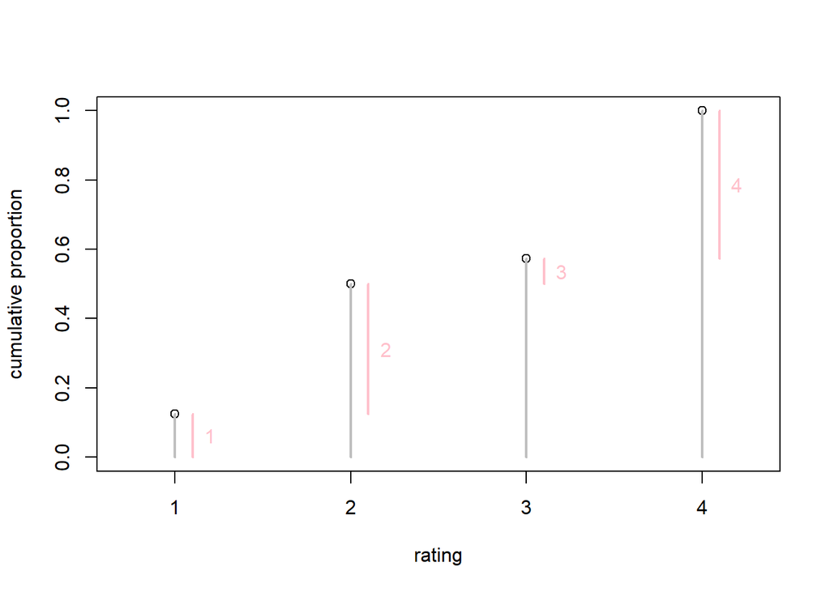

```r
plot( 1:4 , p , xlab="rating" , ylab="cumulative proportion" ,
xlim=c(0.7,4.3) , ylim=c(0,1) , xaxt="n" )
axis( 1 , at=1:4 , labels=1:4 )
# plot gray cumulative probability lines
for ( x in 1:4 ) lines( c(x,x) , c(0,p[x]) , col="gray" , lwd=2 )
# plot blue discrete probability segments
for ( x in 1:4 )
lines( c(x,x)+0.1 , c(p[x]-q[x],p[x]) , col="pink" , lwd=2 )
# add number labels
text( 1:4+0.2 , p-q/2 , labels=1:4 , col="pink" )
```

12M3. You would need to change the poisson liklihood to a binomial likelihood quth q denoting the probability of success, so it would look more like:

Pr(y|p0, q, n)= (1-p0)Binom(y,n,q)